# cifar100_binary

Загружаем данные

```python
import tensorflow as tf
import os
import numpy as np
import math
import matplotlib.pyplot as plt
```

```python
from numpy import loadtxt

def load_data(path, labels_number=1):
  with tf.io.gfile.GFile(path, 'rb') as f:
    data = f.read()
  offset = 0
  max_offset = len(data) - 1
  coarse_labels = []
  fine_labels = []
  images = []
  while offset < max_offset:
    labels = np.frombuffer(
        data, dtype=np.uint8, count=labels_number, offset=offset
    ).reshape((labels_number,))
    offset += labels_number
    img = (
        np.frombuffer(data, dtype=np.uint8, count=3072, offset=offset)
        .reshape((3, 32, 32))
        .transpose((1, 2, 0))
    )
    offset += 3072
    coarse_labels.append(labels[0])
    fine_labels.append(labels[1])
    images.append(img)
  return [np.array(coarse_labels), np.array(fine_labels), np.array(images)]

def load_labels(path):
    return loadtxt(path, comments="#", delimiter=",", unpack=False, dtype='str')

def load_cifar100():
    url = "https://www.cs.toronto.edu/~kriz/cifar-100-binary.tar.gz"
    dataset = tf.keras.utils.get_file("cifar.tar.gz", url,untar=True, cache_dir='.', cache_subdir='')
    dataset_dir = os.path.join(os.path.dirname(dataset), 'cifar-100-binary')
    CY_train, FY_train, X_train = load_data(os.path.join(dataset_dir, 'train.bin'), labels_number=2)
    CY_test, FY_test, X_test = load_data(os.path.join(dataset_dir, 'test.bin'), labels_number=2)
    C_label = load_labels(os.path.join(dataset_dir, 'coarse_label_names.txt'))
    F_label = load_labels(os.path.join(dataset_dir, 'fine_label_names.txt'))

    return X_train, CY_train, FY_train, X_test, CY_test, FY_test, C_label, F_label
```

```python
X_train, CY_train, FY_train, X_test, CY_test, FY_test, C_label, F_label = load_cifar100()
X_train, X_test = X_train / 255.0, X_test / 255.0
```

Предпосмотр датасета

```python
def preview(classnames, label, images, count):
    plt.figure(figsize=(10,10))
    for i in range(count):
        plt.subplot(round(math.sqrt(count)),round(math.sqrt(count)),i+1)
        plt.xticks([])
        plt.yticks([])
        plt.grid(False)
        plt.imshow(images[i])
        plt.xlabel(classnames[label[i]], labelpad=2, fontsize=6)
    plt.show()
```

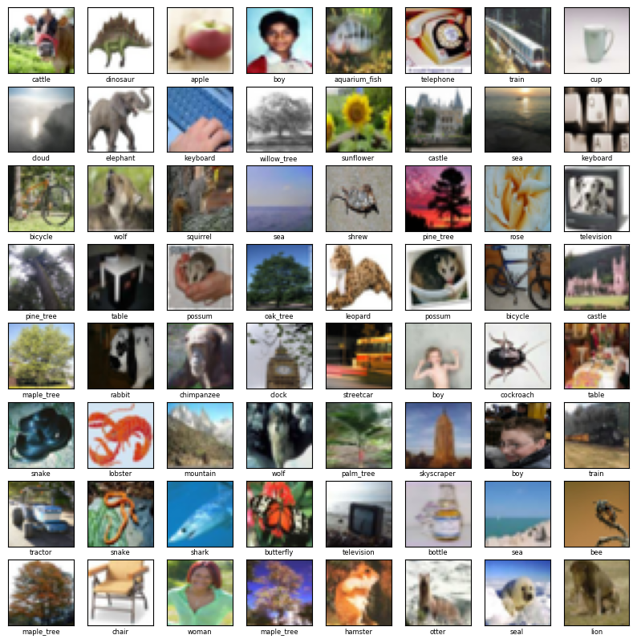

```python
# Вывод изображений с узкими классами, сократим вывод до 64 изображений
preview(F_label, FY_train, X_train, 64)
```

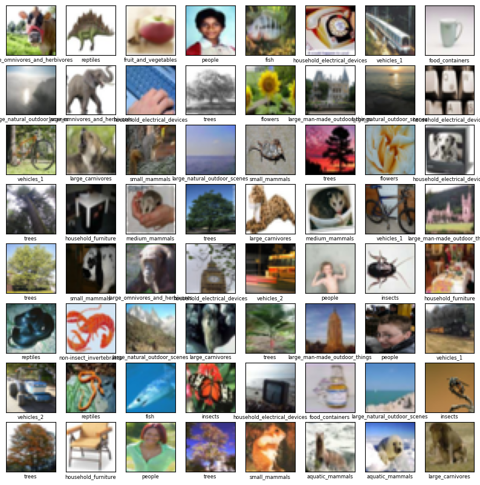

```python
# Вывод изображений с широкими классами
preview(C_label, CY_train, X_train, 64)
```

Построение модели

```python
from tensorflow.keras import layers, models

def getModel():
    model = models.Sequential()
    model.add(layers.Conv2D(32, (3, 3), activation='relu', input_shape=(32, 32, 3)))
    model.add(layers.MaxPooling2D((2, 2)))
    model.add(layers.Conv2D(64, (3, 3), activation='relu'))
    model.add(layers.MaxPooling2D((2, 2)))
    model.add(layers.Conv2D(128, (3, 3), activation='relu'))
    model.add(layers.MaxPooling2D((2, 2)))
    model.add(layers.Flatten())
    model.add(layers.Dense(256, activation='relu'))
    model.add(layers.Dense(128, activation='relu'))
    model.add(layers.Dense(100, activation='softmax'))
    return model
```

```python
model = getModel()
model.summary()
```

```
Model: "sequential"
_________________________________________________________________
 Layer (type)                Output Shape              Param #
=================================================================
 conv2d (Conv2D)             (None, 30, 30, 32)        896

 max_pooling2d (MaxPooling2  (None, 15, 15, 32)        0
 D)

 conv2d_1 (Conv2D)           (None, 13, 13, 64)        18496

 max_pooling2d_1 (MaxPoolin  (None, 6, 6, 64)          0
 g2D)

 conv2d_2 (Conv2D)           (None, 4, 4, 128)         73856

 max_pooling2d_2 (MaxPoolin  (None, 2, 2, 128)         0
 g2D)

 flatten (Flatten)           (None, 512)               0

 dense (Dense)               (None, 256)               131328

 dense_1 (Dense)             (None, 128)               32896

 dense_2 (Dense)             (None, 100)               12900

=================================================================
Total params: 270372 (1.03 MB)
Trainable params: 270372 (1.03 MB)
Non-trainable params: 0 (0.00 Byte)
_________________________________________________________________
```

**Какие элементы сети зависят от количества цветов, какие — от количества классов?**

В качестве входных данных сверточная нейровнная сеть (CNN) принимает тензор формы (высота, ширина, кол-во цветов). В нашем случае, это (32, 32, 3).

CIFAR100 имеет 100 выходных классов, поэтому используется последний плотный слой со 100 выходными данными.

**Объяснение места в модели каждого слоя, обоснование выбора гиперпараметров.**

В сверточной нейронной сети выходы промежуточных слоев образуют матрицу (изображение) или набор матриц (несколько слоёв изображения). Так, например, на вход сверточной нейронной сети можно подавать три слоя изображения (R-, G-, B-каналы изображения). Основными видами слоев в сверточной нейронной сети являются сверточные слои (англ. convolutional layer), пулинговые слои (англ. pooling layer) и полносвязные слои (англ. fully-connected layer).

*Сверточный слой* нейронной сети представляет из себя применение операции свертки к выходам с предыдущего слоя, где веса ядра свертки являются обучаемыми параметрами. Еще один обучаемый вес используется в качестве константного сдвига (англ. bias). При этом есть несколько важных деталей:

- В одном сверточном слое может быть несколько сверток. В этом случае для каждой свертки на выходе получится своё изображение.
- Ядра свертки могут быть трёхмерными.
- Применение операции свертки уменьшает изображение. Также пиксели, которые находятся на границе изображения участвуют в меньшем количестве сверток, чем внутренние. В связи с этим в сверточных слоях используется дополнение изображения (англ. padding). Выходы с предыдущего слоя дополняются пикселями так, чтобы после свертки сохранился размер изображения. Такие свертки называют одинаковыми (англ. same convolution), а свертки без дополнения изображения называются правильными (англ. valid convolution).
- Еще одним параметром сверточного слоя является сдвиг (англ. stride). Хоть обычно свертка применяется подряд для каждого пикселя, иногда используется сдвиг, отличный от единицы — скалярное произведение считается не со всеми возможными положениями ядра, а только с положениями, кратными некоторому сдвигу S.
- Высота и ширина окна свертки подбирается экспериментально и не должна быть больше начального размера изображения.

*Пулинговый слой* призван снижать размерность изображения. Чаще всего используется функция максимума (англ. max pooling) или (взвешенного) среднего (англ. (weighted) average pooling). Обучаемых параметров у этого слоя нет.

[output not shown]

**model.add(layers.Conv2D(32, (3, 3), activation='relu', input_shape=(32, 32, 3)))** | |

Сверточный 2D-слой. Число выходных фильтров в свертке (размерность выхода) filters W2=32. Высота и ширина окна свертки kernel_size = (F, F) = (3,3). Функция активации = 'relu' *(f(x) = max{0, z})*. input_shape = (W1, H1, D) | | *Layer (type)* | *Output Shape* | *Param* | | conv2d (Conv2D) | (None, 30, 30, 32) | 896 | | | None - кол-во пакетов (единый пакет - None)  
30, 30 = (начальная ширина W1/высота H1 - размер ядра F + 2*отступ)/шаг + 1 = (32 - 3 +20)/1+1 - итоговая ширина, высота  
32 - число выходных фильтров в свертке (размерность выхода) | 896 = W2 \ (D * F * F + 1) = 32 * (3*3*3+1) | | | | | |

**model.add(layers.MaxPooling2D((2, 2)))** | |

Cлой подвыборки, снижающий размерность поступивших на него данных. Размер окна подвыборки pool_size=(2, 2)=(F, F). Шаг подвыборки strides = None, что означает, что strides = pool_size=(2, 2) = S = F. | | *Layer (type)* | *Output Shape* | *Param* | | max_pooling2d (MaxPooling2D) | (None, 15, 15, 32)| 0 | | | None - кол-во пакетов (единый пакет - None)  
15, 15 = (W1/H1 - F)/S+1 = (30 - 2)/2+1  
32 - число выходных фильтров в свертке (размерность выхода) | 0 | | | | | |

**model.add(layers.Conv2D(64, (3, 3), activation='relu'))** | |

Сверточный 2D-слой. Число выходных фильтров в свертке (размерность выхода) filters W2=64. Высота и ширина окна свертки kernel_size = (F, F) = (3,3). Функция активации = 'relu'. input_shape = (W1=15, H1=15, D=32) | | *Layer (type)* | *Output Shape* | *Param* | | conv2d_1 (Conv2D) | (None, 13, 13, 64) | 18496 | | | None - кол-во пакетов (единый пакет - None)  
13, 13 = (начальная ширина W1/высота H1 - размер ядра F + 2*отступ)/шаг + 1 = (15 - 3 +20)/1+1 - итоговая ширина, высота  
64 - число выходных фильтров в свертке (размерность выхода) | 18496 = W2 \ (D * F * F + 1) = 64 * (32*3*3+1) | | | | | |

**model.add(layers.MaxPooling2D((2, 2)))** | |

Cлой подвыборки, снижающий размерность поступивших на него данных. Размер окна подвыборки pool_size=(2, 2)=(F, F). Шаг подвыборки strides = None, что означает, что strides = pool_size=(2, 2) = S = F. | | *Layer (type)* | *Output Shape* | *Param* | | max_pooling2d_1 (MaxPooling2D) | (None, 6, 6, 64)| 0 | | | None - кол-во пакетов (единый пакет - None)  
6, 6 = (W1/H1 - F)/S+1 = (13 - 2)/2+1  
64 - число выходных фильтров в свертке (размерность выхода) | 0 | | | | | |

**model.add(layers.Conv2D(128, (3, 3), activation='relu'))** | |

Сверточный 2D-слой. Число выходных фильтров в свертке (размерность выхода) filters W2=128. Высота и ширина окна свертки kernel_size = (F, F) = (3,3). Функция активации = 'relu'. input_shape = (W1=6, H1=6, D=64) | | *Layer (type)* | *Output Shape* | *Param* | | conv2d_2 (Conv2D) | (None, 4, 4, 128) | 73856 | | | None - кол-во пакетов (единый пакет - None)  
4, 4 = (начальная ширина W1/высота H1 - размер ядра F + 2*отступ)/шаг + 1 = (6 - 3 +20)/1+1 - итоговая ширина, высота  
128 - число выходных фильтров в свертке (размерность выхода) | 73856 = W2 \ (D * F * F + 1) = 128 * (64*3*3+1) | | | | | |

**model.add(layers.MaxPooling2D((2, 2)))** | |

Cлой подвыборки, снижающий размерность поступивших на него данных. Размер окна подвыборки pool_size=(2, 2)=(F, F). Шаг подвыборки strides = None, что означает, что strides = pool_size=(2, 2) = S = F. | | *Layer (type)* | *Output Shape* | *Param* | | max_pooling2d_2 (MaxPooling2D) | (None, 2, 2, 128)| 0 | | | None - кол-во пакетов (единый пакет - None)  
2, 2 = (W1/H1 - F)/S+1 = (4 - 2)/2+1  
128 - число выходных фильтров в свертке (размерность выхода) | 0 | | | | | |

**model.add(layers.Flatten())** | |

Cлой слой, преобразующий 2D-данные в 1D-данные. | | *Layer (type)* | *Output Shape* | *Param* | | flatten (Flatten) | (None, 512) | 0 | | | None - кол-во пакетов (единый пакет - None)  
512=W1*H1*D=2*2*128 - одномерные данные | 0 | | | | | |

**model.add(layers.Dense(256, activation='relu'))** | |

Полносвязный слой. Размер выхода слоя units = U = 256. W=512 - размер входного слоя. Функция активации = 'relu'. | | *Layer (type)* | *Output Shape* | *Param* | | dense (Dense) | (None, 256) | 131328 | | | None - кол-во пакетов (единый пакет - None)  
256 - размер выхода | 131328 = W * U + U = 512 * 256 + 256 | | | | | |

**model.add(layers.Dense(128, activation='relu'))** | |

Полносвязный слой. Размер выхода слоя units = U = 128. W=256 - размер входного слоя. Функция активации = 'relu'. | | *Layer (type)* | *Output Shape* | *Param* | | dense_1 (Dense) | (None, 128) | 32896 | | | None - кол-во пакетов (единый пакет - None)  
128 - размер выхода | 32896 = W * U + U = 256 * 128 + 128 | | | | | |

**model.add(layers.Dense(100, activation='softmax'))** | |

Полносвязный слой. Размер выхода слоя units = U = 100. W=128 - размер входного слоя. Функция активации = 'softmax' нормализованная экспоненциальная функция преобразует вектор из действительных чисел в распределение вероятностей возможных результатов. | | *Layer (type)* | *Output Shape* | *Param* | | dense_2 (Dense) | (None, 100) | 12900 | | | None - кол-во пакетов (единый пакет - None)  
100 - размер выхода | 12900 = W * U + U = 128 * 100 + 100 |

При компиляции модели применяется функция потерь - категориальная перекрестная энтропия (tf.keras.losses.SparseCategoricalCrossentropy). В качестве оптимизатора - вариант стохастической оптимизации ('adam'). Для оценки эффективности модели используется точность ('accuracy').

```python
def getCompiledModel():
    model = getModel()
    model.compile(loss=tf.keras.losses.SparseCategoricalCrossentropy(from_logits=True),
              optimizer='adam',
              metrics=['accuracy'])
    return model
```

Обучение на 20 широких классах

```python
model = getCompiledModel()
```

```python
his = model.fit(X_train, CY_train, epochs=20)
```

```
C:\Users\Mark Bernstorf\AppData\Local\Programs\Python\Python311\Lib\site-packages\keras\src\backend.py:5714: UserWarning: "`sparse_categorical_crossentropy` received `from_logits=True`, but the `output` argument was produced by a Softmax activation and thus does not represent logits. Was this intend…
  output, from_logits = _get_logits(
```

Экспорт обученной модели в файл

```python
model.save('./coarse_model.keras')
```

Точность на тестовых данных

```python
С_test_loss, С_test_acc = model.evaluate(X_test, CY_test)
print('Точность на тестовых данных:', С_test_acc)
```

```
Точность на тестовых данных: 0.48750001192092896
```

Предсказания

```python
# Получаем набор вероятностей определения каждой категории
С_predictions = model.predict(X_test)

# Находим максимальные вероятности в наборе предсказаний
С_predictions = np.argmax(С_predictions, axis=-1)

# Отображаем оценку модели
from sklearn.metrics import classification_report

print(classification_report(CY_test, С_predictions, target_names=C_label))
```

```
                                precision    recall  f1-score   support

               aquatic_mammals       0.34      0.42      0.38       500
                          fish       0.47      0.46      0.47       500
                       flowers       0.63      0.72      0.67       500
               food_containers       0.49      0.48      0.48       500
          fruit_and_vegetables       0.54      0.65      0.59       500
  household_electrical_devices       0.41      0.42      0.41       500
           household_furniture       0.53      0.60      0.56       500
                       insects       0.56      0.39      0.46       500
              large_carnivores       0.44      0.33      0.37       500
 large_man-made_outdoor_things       0.53      0.64      0.58       500
  large_natural_outdoor_scenes       0.68      0.66      0.67       500
large_omnivores_and_herbivores       0.39      0.42      0.41       500
                medium_mammals       0.38      0.32      0.35       500
      non-insect_invertebrates       0.33      0.29      0.31       500
                        people       0.59      0.53      0.56       500
                      reptiles       0.33      0.29      0.31       500
                 small_mammals       0.31      0.39      0.35       500
                         trees       0.72      0.81      0.76       500
                    vehicles_1       0.58      0.46      0.52       500
                    vehicles_2       0.52      0.47      0.49       500

                      accuracy                           0.49     10000
                     macro avg       0.49      0.49      0.48     10000
                  weighted avg       0.49      0.49      0.48     10000
```

Обучение на 100 узких классах

```python
tf.keras.backend.clear_session()

model = model = getCompiledModel()

his = model.fit(X_train, FY_train, epochs=20)
```

```
C:\Users\Mark Bernstorf\AppData\Local\Programs\Python\Python311\Lib\site-packages\keras\src\backend.py:5714: UserWarning: "`sparse_categorical_crossentropy` received `from_logits=True`, but the `output` argument was produced by a Softmax activation and thus does not represent logits. Was this intend…
  output, from_logits = _get_logits(
```

Экспорт обученной модели в файл

```python
model.save('./fine_model.keras')
```

Точность на тестовых данных

```python
F_test_loss, F_test_acc = model.evaluate(X_test, FY_test)
print('Точность на тестовых данных:', F_test_acc)
```

```
Точность на тестовых данных: 0.35510000586509705
```

Предсказания

```python
# Получаем набор вероятностей определения каждой категории
F_predictions = model.predict(X_test)

# Находим максимальные вероятности в наборе предсказаний
F_predictions = np.argmax(F_predictions, axis=-1)

# Отображаем оценку модели
print(classification_report(FY_test, F_predictions, target_names=F_label))
F_report = classification_report(FY_test, F_predictions, target_names=F_label, output_dict = True)
```

```
               precision    recall  f1-score   support

        apple       0.59      0.74      0.66       100
aquarium_fish       0.47      0.41      0.44       100
         baby       0.21      0.26      0.23       100
         bear       0.20      0.18      0.19       100
       beaver       0.19      0.12      0.15       100
          bed       0.20      0.25      0.23       100
          bee       0.32      0.32      0.32       100
       beetle       0.44      0.36      0.40       100
      bicycle       0.40      0.32      0.36       100
       bottle       0.41      0.49      0.45       100
         bowl       0.14      0.13      0.14       100
          boy       0.14      0.07      0.09       100
       bridge       0.30      0.32      0.31       100
          bus       0.29      0.43      0.35       100
    butterfly       0.27      0.25      0.26       100
        camel       0.30      0.16      0.21       100
          can       0.42      0.38      0.40       100
       castle       0.44      0.57      0.50       100
  caterpillar       0.58      0.18      0.27       100
       cattle       0.30      0.30      0.30       100
        chair       0.63      0.62      0.62       100
   chimpanzee       0.63      0.43      0.51       100
        clock       0.31      0.35      0.33       100
        cloud       0.42      0.59      0.49       100
    cockroach       0.66      0.51      0.58       100
        couch       0.22      0.22      0.22       100
         crab       0.31      0.19      0.23       100
    crocodile       0.23      0.27      0.25       100
          cup       0.50      0.49      0.49       100
     dinosaur       0.36      0.35      0.36       100
      dolphin       0.38      0.43      0.40       100
     elephant       0.25      0.37      0.30       100
     flatfish       0.20      0.40      0.26       100
       forest       0.40      0.34      0.37       100
          fox       0.39      0.36      0.37       100
         girl       0.27      0.29      0.28       100
      hamster       0.33      0.32      0.33       100
        house       0.21      0.26      0.24       100
```

[output cut: 51 more lines]

```
      tractor       0.35      0.37      0.36       100
        train       0.23      0.22      0.23       100
        trout       0.39      0.46      0.42       100
        tulip       0.37      0.22      0.27       100
       turtle       0.15      0.17      0.16       100
     wardrobe       0.56      0.73      0.63       100
        whale       0.39      0.45      0.42       100
  willow_tree       0.33      0.33      0.33       100
         wolf       0.28      0.38      0.32       100
        woman       0.16      0.18      0.17       100
         worm       0.40      0.21      0.27       100

     accuracy                           0.36     10000
    macro avg       0.36      0.36      0.35     10000
 weighted avg       0.36      0.36      0.35     10000
```

Сравнение

Обобщение предсказаний по узким меткам до метки их широкого класса

```python
# Определение по узкой категории широкой
def init_fine_map():
    map = {
        "aquatic_mammals": ["beaver", "dolphin", "otter", "seal", "whale"],
        "fish": ["aquarium_fish", "flatfish", "ray", "shark", "trout"],
        "flowers": ["orchid", "poppy", "rose", "sunflower", "tulip"],
        "food_containers": ["bottle", "bowl", "can", "cup", "plate"],
        "fruit_and_vegetables": ["apple", "mushroom", "orange", "pear", "sweet_pepper"],
        "household_electrical_devices": ["clock", "keyboard", "lamp", "telephone", "television"],
        "household_furniture": ["bed", "chair", "couch", "table", "wardrobe"],
        "insects": ["bee", "beetle", "butterfly", "caterpillar", "cockroach"],
        "large_carnivores": ["bear", "leopard", "lion", "tiger", "wolf"],
        "large_man-made_outdoor_things": ["bridge", "castle", "house", "road", "skyscraper"],
        "large_natural_outdoor_scenes": ["cloud", "forest", "mountain", "plain", "sea"],
        "large_omnivores_and_herbivores": ["camel", "cattle", "chimpanzee", "elephant", "kangaroo"],
        "medium_mammals": ["fox", "porcupine", "possum", "raccoon", "skunk"],
        "non-insect_invertebrates": ["crab", "lobster", "snail", "spider", "worm"],
        "people": ["baby", "boy", "girl", "man", "woman"],
        "reptiles": ["crocodile", "dinosaur", "lizard", "snake", "turtle"],
        "small_mammals": ["hamster", "mouse", "rabbit", "shrew", "squirrel"],
        "trees": ["maple_tree", "oak_tree", "palm_tree", "pine_tree", "willow_tree"],
        "vehicles_1": ["bicycle", "bus", "motorcycle", "pickup_truck", "train"],
        "vehicles_2": ["lawn_mower", "rocket", "streetcar", "tank", "tractor"],
    }
    dict = {}
    for label in F_label:
        for key in map:
            if label in map[key]:
                dict.update({label: key})
                break
    return dict

fine_to_coarse = init_fine_map()
```

```python
FC = lambda i: fine_to_coarse[F_label[i]]
CF_predictions = np.array([FC(i) for i in F_predictions])
C_index = lambda i: np.where(C_label == i)[0][0]
CF_predictions = np.array([C_index(i) for i in CF_predictions])
```

Оценка обобщенных предсказаний по узким меткам до метки их широкого класса

```python
print(classification_report(CY_test, CF_predictions, target_names=C_label))
CF_report = classification_report(CY_test, CF_predictions, target_names=C_label, output_dict = True)
```

```
                                precision    recall  f1-score   support

               aquatic_mammals       0.39      0.41      0.40       500
                          fish       0.40      0.44      0.42       500
                       flowers       0.64      0.69      0.67       500
               food_containers       0.48      0.50      0.49       500
          fruit_and_vegetables       0.52      0.52      0.52       500
  household_electrical_devices       0.45      0.46      0.45       500
           household_furniture       0.52      0.56      0.54       500
                       insects       0.55      0.43      0.48       500
              large_carnivores       0.42      0.44      0.43       500
 large_man-made_outdoor_things       0.51      0.66      0.58       500
  large_natural_outdoor_scenes       0.67      0.68      0.67       500
large_omnivores_and_herbivores       0.41      0.40      0.41       500
                medium_mammals       0.39      0.48      0.43       500
      non-insect_invertebrates       0.40      0.29      0.34       500
                        people       0.59      0.55      0.57       500
                      reptiles       0.33      0.28      0.30       500
                 small_mammals       0.34      0.31      0.32       500
                         trees       0.74      0.72      0.73       500
                    vehicles_1       0.53      0.53      0.53       500
                    vehicles_2       0.51      0.49      0.50       500

                      accuracy                           0.49     10000
                     macro avg       0.49      0.49      0.49     10000
                  weighted avg       0.49      0.49      0.49     10000
```

Оценка предсказаний при обучении на широких метках

```python
print(classification_report(CY_test, С_predictions, target_names=C_label))
C_report = classification_report(CY_test, С_predictions, target_names=C_label, output_dict = True)
```

```
                                precision    recall  f1-score   support

               aquatic_mammals       0.34      0.42      0.38       500
                          fish       0.47      0.46      0.47       500
                       flowers       0.63      0.72      0.67       500
               food_containers       0.49      0.48      0.48       500
          fruit_and_vegetables       0.54      0.65      0.59       500
  household_electrical_devices       0.41      0.42      0.41       500
           household_furniture       0.53      0.60      0.56       500
                       insects       0.56      0.39      0.46       500
              large_carnivores       0.44      0.33      0.37       500
 large_man-made_outdoor_things       0.53      0.64      0.58       500
  large_natural_outdoor_scenes       0.68      0.66      0.67       500
large_omnivores_and_herbivores       0.39      0.42      0.41       500
                medium_mammals       0.38      0.32      0.35       500
      non-insect_invertebrates       0.33      0.29      0.31       500
                        people       0.59      0.53      0.56       500
                      reptiles       0.33      0.29      0.31       500
                 small_mammals       0.31      0.39      0.35       500
                         trees       0.72      0.81      0.76       500
                    vehicles_1       0.58      0.46      0.52       500
                    vehicles_2       0.52      0.47      0.49       500

                      accuracy                           0.49     10000
                     macro avg       0.49      0.49      0.48     10000
                  weighted avg       0.49      0.49      0.48     10000
```

Исследование с помощью графиков метрики предсказания для каких узких классов более всего отличаются от метрик их более широких классов

```python
# Точность распознавания узкого класса
F_precision =  lambda i: F_report[i]['precision']
F_precisions = np.array([F_precision(i) for i in F_label])

#Точность распознавания широкого класса по узкому
CF_precision =  lambda i: CF_report[fine_to_coarse[i]]['precision']
CF_precisions = np.array([CF_precision(i) for i in F_label])

# Точность распознавания соответствующего широкого класса
C_precision =  lambda i: C_report[fine_to_coarse[i]]['precision']
C_precisions = np.array([C_precision(i) for i in F_label])
```

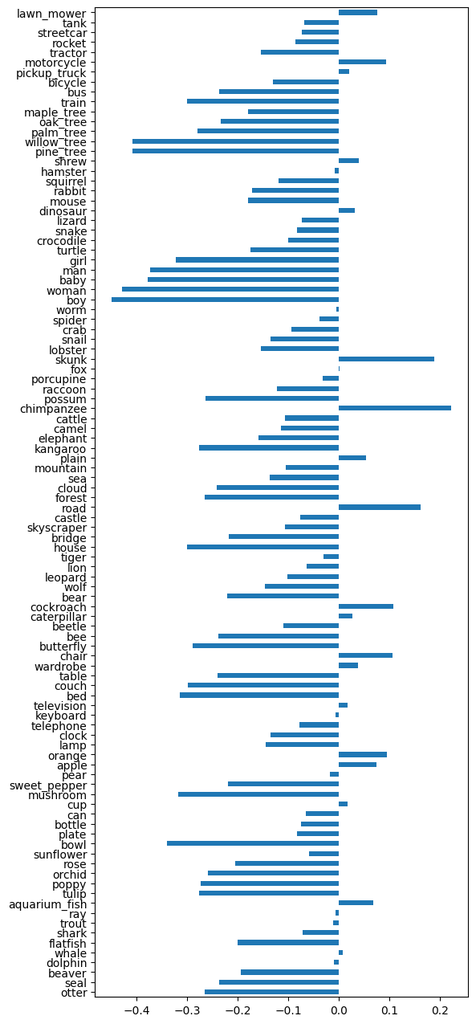

```python
import pandas as pd

df = pd.DataFrame(
    {
     'label': F_label,
     'c_label': np.array([fine_to_coarse[i] for i in F_label]),
     'F_CF': F_precisions - CF_precisions,
     'F_C': F_precisions - C_precisions,
     'CF_C': CF_precisions - C_precisions,
    })

# График различия точности распознавания узкого класса и точности распознавания широкого класса по узкому
df.sort_values(by=['c_label', 'F_CF'],ascending=True).plot.barh(y='F_CF', x='label', legend=False, figsize=(6, 16), ylabel='')
```

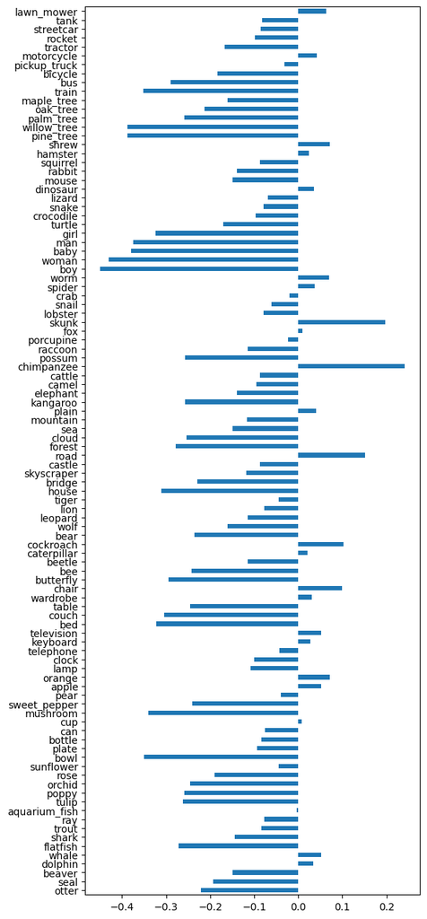

```python
# График различия точности распознавания узкого класса и точности распознавания широкого класса
df.sort_values(by=['c_label', 'F_C'],ascending=True).plot.barh(y='F_C', x='label', legend=False, figsize=(6, 16), ylabel='')
```

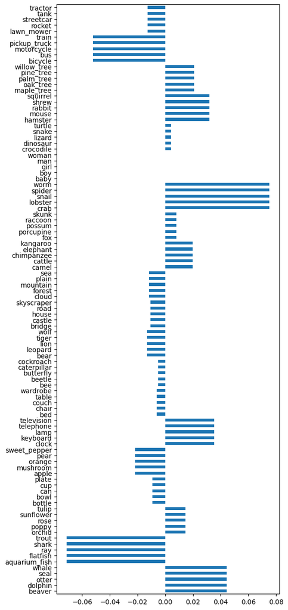

```python
# График различия точности распознавания широкого класса по узкому и точности распознавания широкого класса
df.sort_values(by=['c_label', 'CF_C'],ascending=True).plot.barh(y='CF_C', x='label', legend=False, figsize=(6, 16), ylabel='')
```